# R语言与数据可视化

## 3.13 分位图

分位图展示分位数回归结果。

```
## Smoothing formula not specified. Using: y ~ x
```

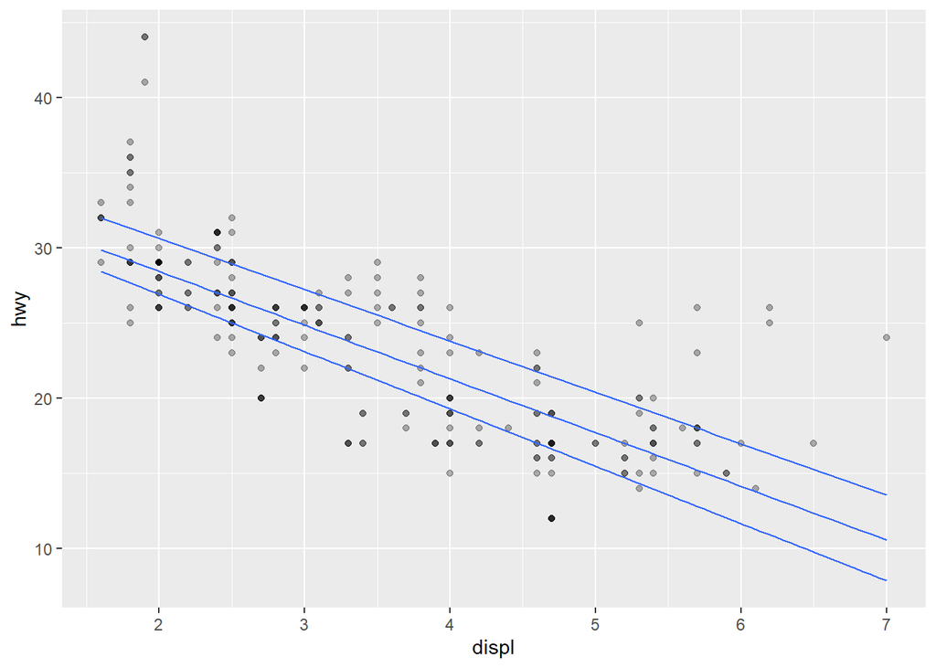

```r
# 分位数回归
# 注意：geom_quantile需要quantreg包
library(quantreg)

ggplot(mpg, aes(x = displ, y = hwy)) +
  geom_point(alpha = 0.3) +
  geom_quantile(quantiles = c(0.25, 0.5, 0.75)) +
  scale_color_manual(values = c("0.25" = "red", "0.5" = "blue", "0.75" = "green"))
```

**小结**：分位数回归展示不同分位数的趋势。需要安装`quantreg`包。

## 3.14 文本注释

添加文本和标签注释。

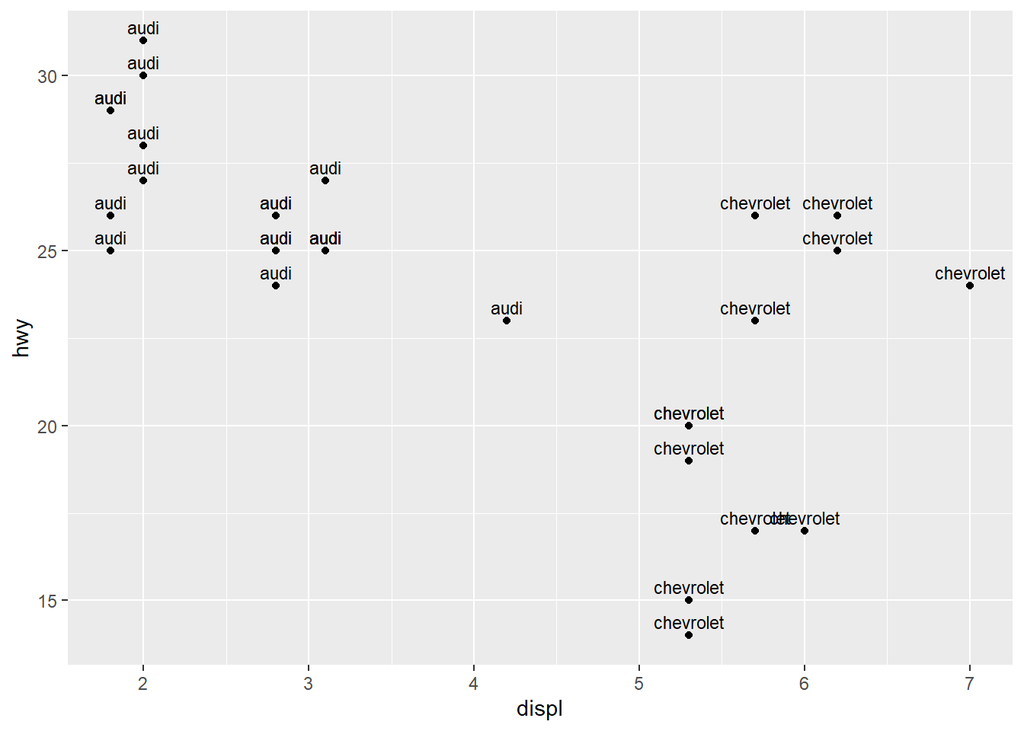

```r
# geom_text()添加文本
ggplot(mpg[1:30, ], aes(x = displ, y = hwy)) +
  geom_point() +
  geom_text(aes(label = manufacturer), vjust = -0.5, size = 3)
```

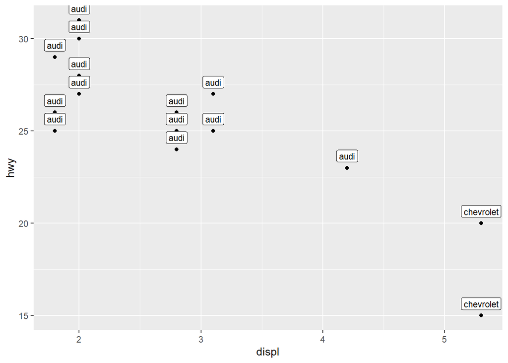

```r
# geom_label()添加带背景的标签
ggplot(mpg[1:20, ], aes(x = displ, y = hwy)) +
  geom_point() +
  geom_label(aes(label = manufacturer), vjust = -0.5, size = 3)
```

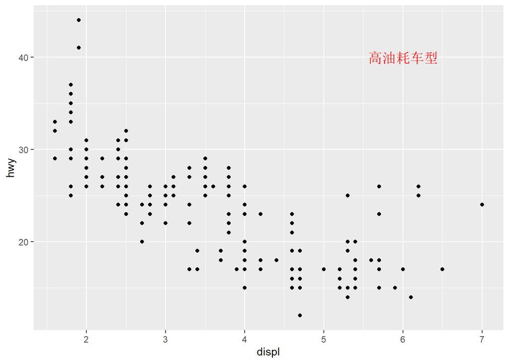

```r
# annotate()添加固定文本
ggplot(mpg, aes(x = displ, y = hwy)) +
  geom_point() +
  annotate("text", x = 6, y = 40, label = "高油耗车型",
           color = "red", size = 5)
```

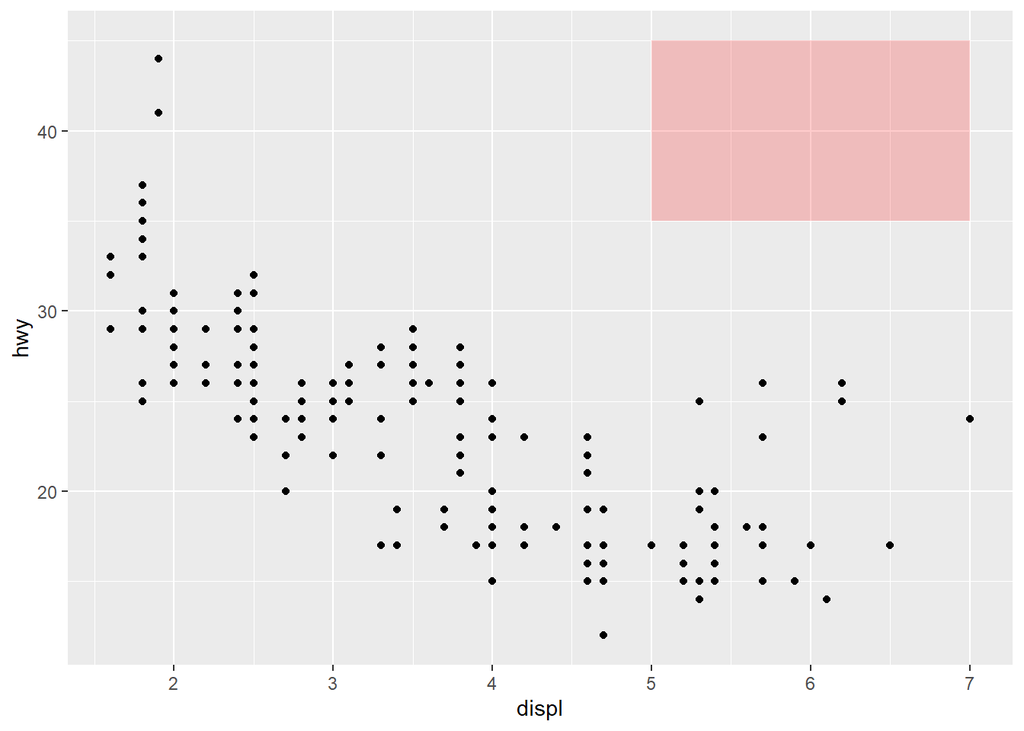

```r
# 添加矩形注释
ggplot(mpg, aes(x = displ, y = hwy)) +
  geom_point() +
  annotate("rect", xmin = 5, xmax = 7, ymin = 35, ymax = 45,
           alpha = 0.2, fill = "red")
```

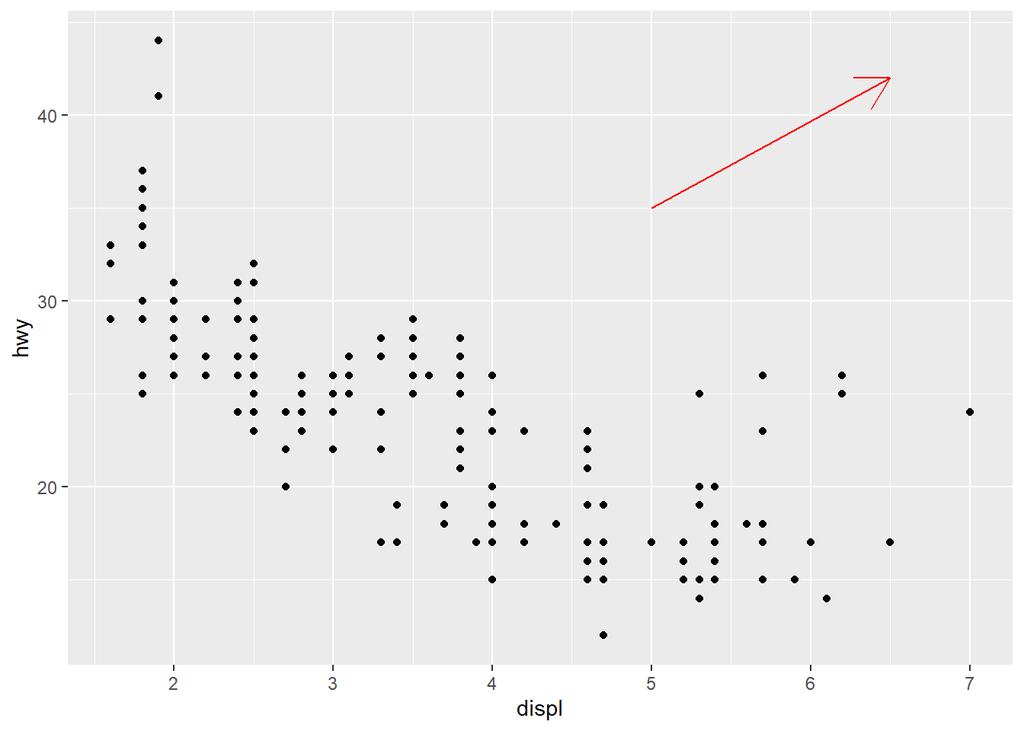

```r
# 添加箭头
ggplot(mpg, aes(x = displ, y = hwy)) +
  geom_point() +
  annotate("segment", x = 5, xend = 6.5, y = 35, yend = 42,
           arrow = arrow(), color = "red")
```

**小结**：`geom_text()`映射变量，`annotate()`添加固定注释。

## 3.15 热图

热图用颜色展示二维数据。

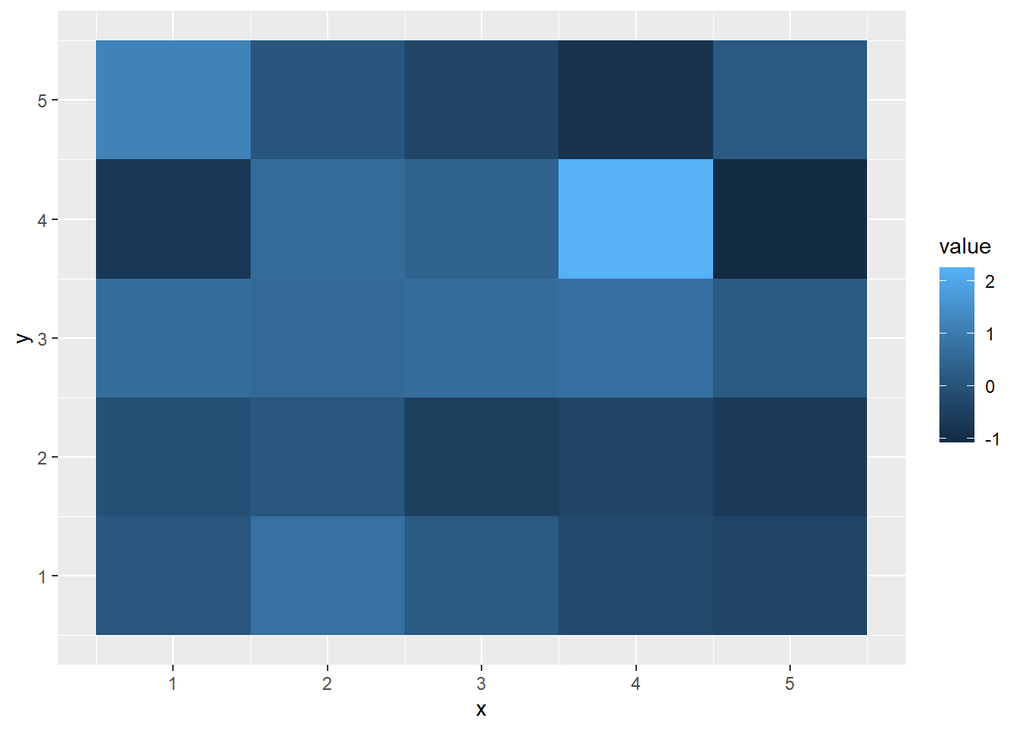

```r
# 创建矩阵数据
df <- expand.grid(x = 1:5, y = 1:5)
df$value <- rnorm(25)

# geom_tile()
ggplot(df, aes(x = x, y = y, fill = value)) +
  geom_tile()
```

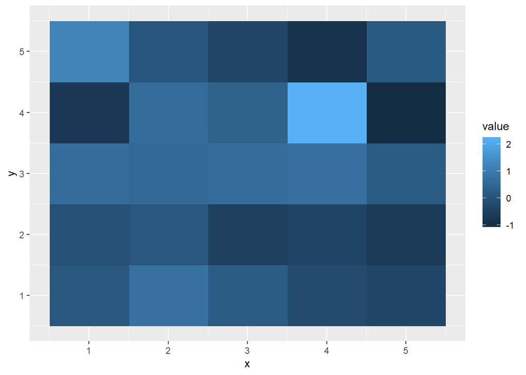

```r
# geom_raster()（更高效）
ggplot(df, aes(x = x, y = y, fill = value)) +
  geom_raster()
```

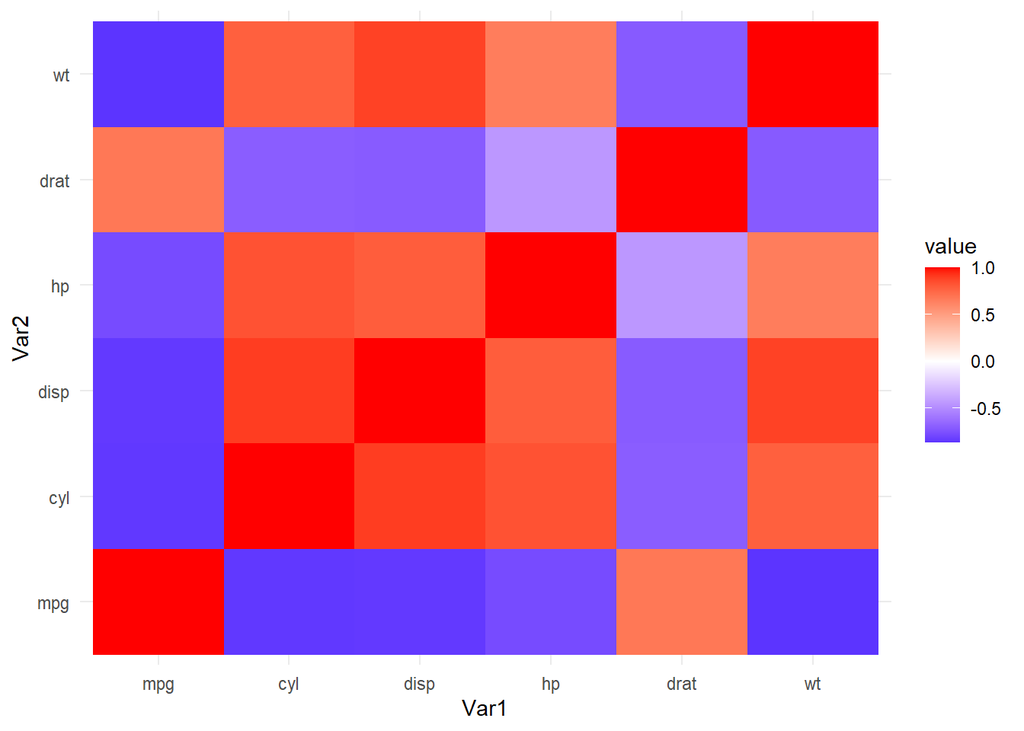

```r
# 相关性热图
cor_matrix <- cor(mtcars[, 1:6])
cor_df <- reshape2::melt(cor_matrix)

ggplot(cor_df, aes(x = Var1, y = Var2, fill = value)) +
  geom_tile() +
  scale_fill_gradient2(low = "blue", mid = "white", high = "red",
                       midpoint = 0) +
  theme_minimal()
```

**小结**：`geom_tile()`和`geom_raster()`用于创建热图。

## 第三章总结

| 图形类型 | 几何对象 | 用途 |
| --- | --- | --- |
| 散点图 | `geom_point()` | 两变量关系 |
| 折线图 | `geom_line()` | 时间序列 |
| 柱状图 | `geom_bar()`/`geom_col()` | 分类变量频数 |
| 直方图 | `geom_histogram()` | 连续变量分布 |
| 密度图 | `geom_density()` | 分布密度 |
| 箱线图 | `geom_boxplot()` | 分布和异常值 |
| 小提琴图 | `geom_violin()` | 分布形状 |
| 面积图 | `geom_area()` | 数量变化 |
| 饼图 | `geom_bar()` + `coord_polar()` | 占比 |
| 热图 | `geom_tile()` | 二维数据 |

# 第四章：图形属性与标度调整

标度（Scales）控制数据值到图形属性的映射方式。本章详细介绍各种标度函数的使用方法。

## 4.1 颜色标度

颜色是最常用的图形属性之一。

### 离散颜色标度

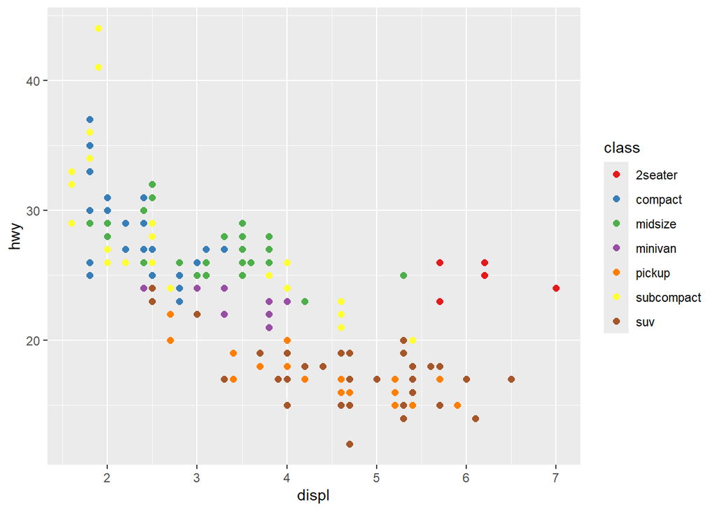

```r
# 离散变量的颜色映射

# scale_color_brewer()：使用ColorBrewer调色板
ggplot(mpg, aes(x = displ, y = hwy, color = class)) +
  geom_point(size = 2) +
  scale_color_brewer(palette = "Set1")
```

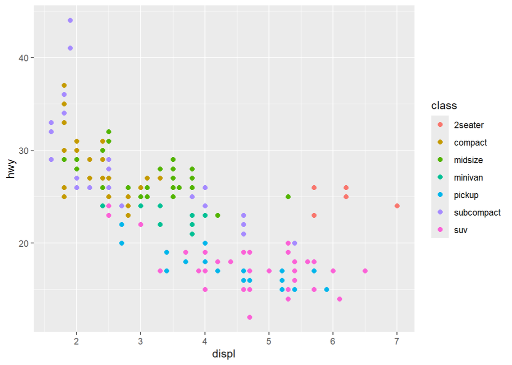

```r
# 查看可用的调色板
# RColorBrewer::display.brewer.all()

# 常用调色板
# 分类调色板：Set1, Set2, Set3, Dark2, Paired等
# 序列调色板：Blues, Greens, Reds, Oranges等
# 发散调色板：RdBu, RdYlBu, Spectral等

# scale_color_hue()：使用HCL色彩空间
ggplot(mpg, aes(x = displ, y = hwy, color = class)) +
  geom_point(size = 2) +
  scale_color_hue(h = c(0, 360) + 15, l = 65, c = 100)
```

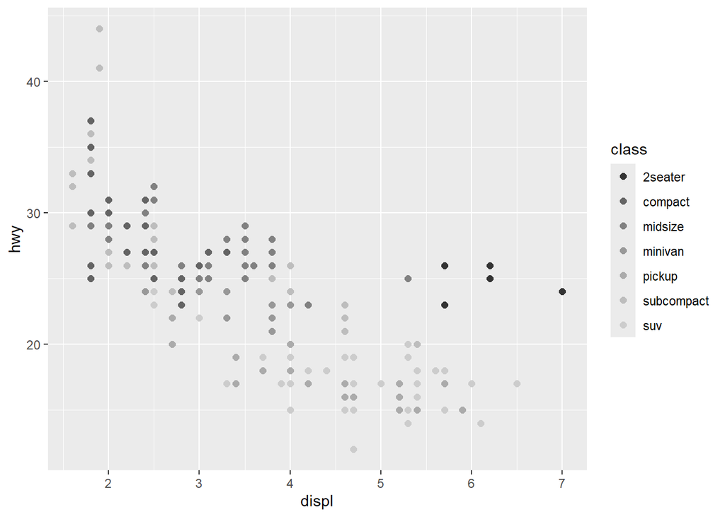

```r
# scale_color_grey()：灰度调色板
ggplot(mpg, aes(x = displ, y = hwy, color = class)) +
  geom_point(size = 2) +
  scale_color_grey(start = 0.2, end = 0.8)
```

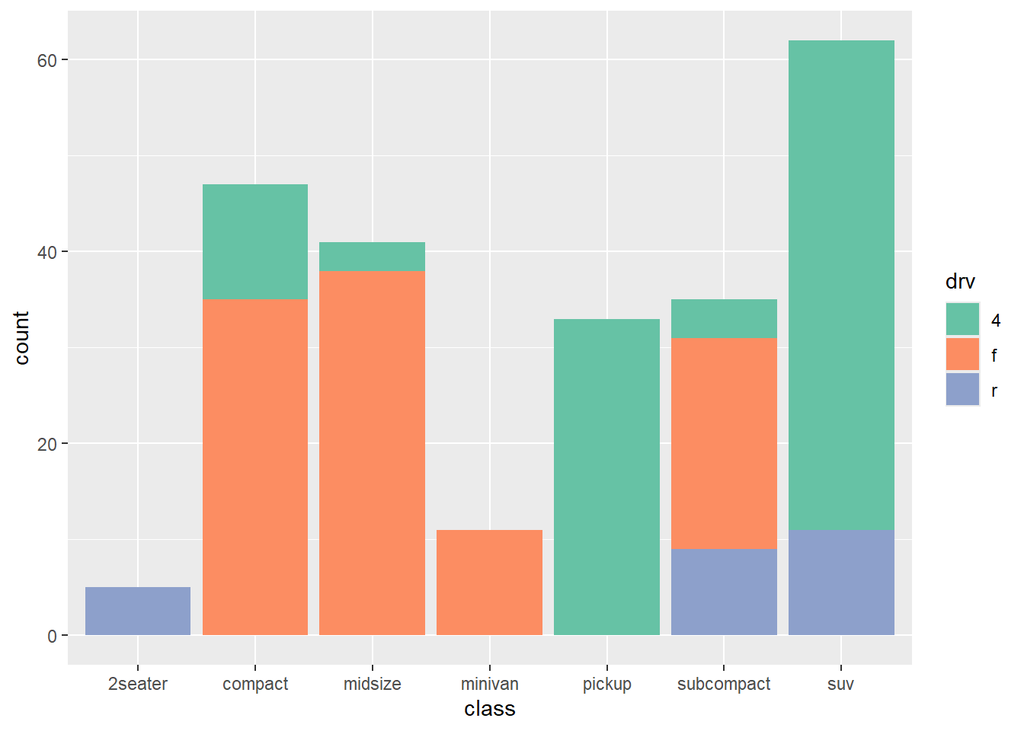

```r
# 填充颜色（用于柱状图、箱线图等）
ggplot(mpg, aes(x = class, fill = drv)) +
  geom_bar() +
  scale_fill_brewer(palette = "Set2")
```

### 连续颜色标度

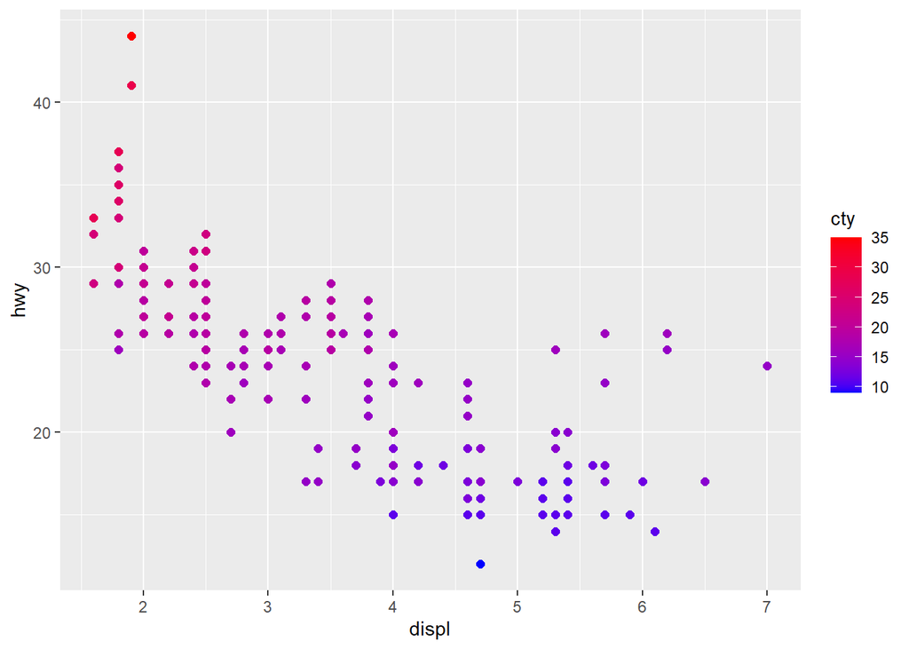

```r
# 连续变量的颜色映射

# scale_color_gradient()：双色渐变
ggplot(mpg, aes(x = displ, y = hwy, color = cty)) +
  geom_point(size = 2) +
  scale_color_gradient(low = "blue", high = "red")
```

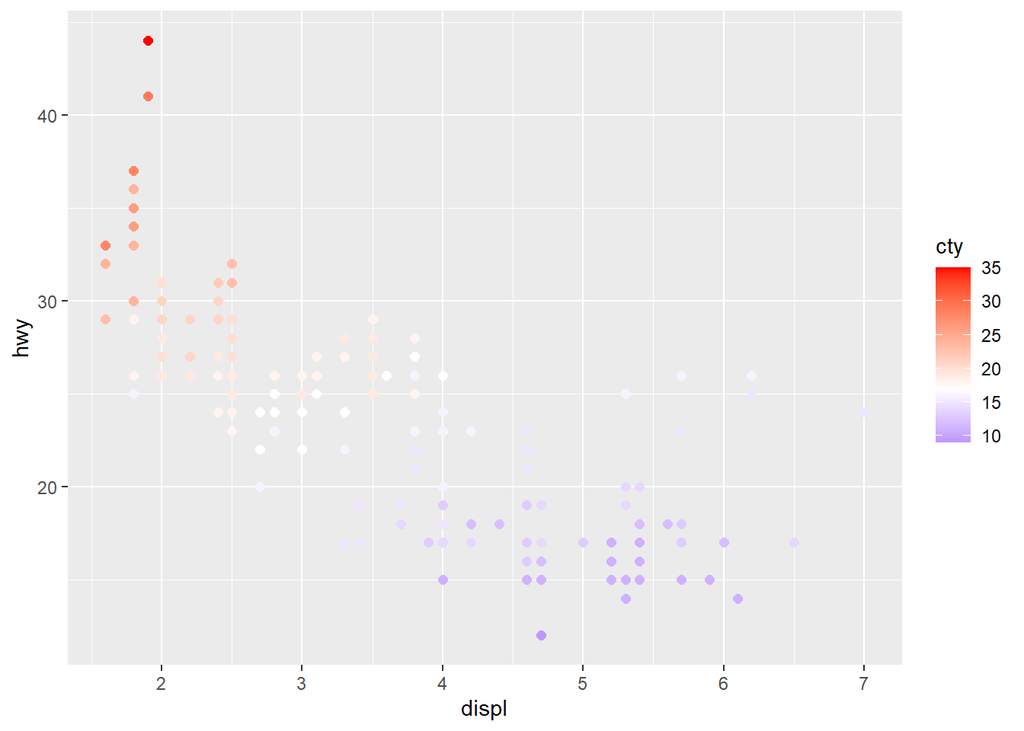

```r
# scale_color_gradient2()：三色渐变（发散）
ggplot(mpg, aes(x = displ, y = hwy, color = cty)) +
  geom_point(size = 2) +
  scale_color_gradient2(low = "blue", mid = "white", high = "red",
                        midpoint = median(mpg$cty))
```

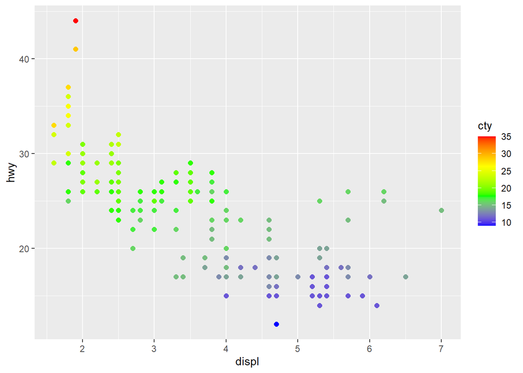

```r
# scale_color_gradientn()：多色渐变
ggplot(mpg, aes(x = displ, y = hwy, color = cty)) +
  geom_point(size = 2) +
  scale_color_gradientn(colors = c("blue", "green", "yellow", "red"))
```

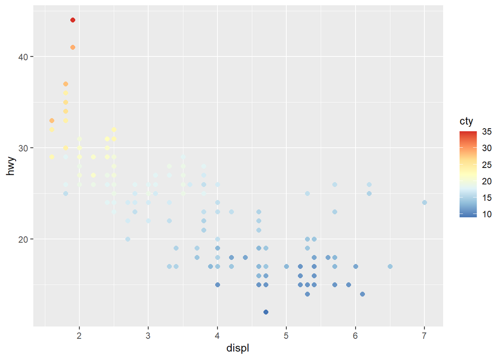

```r
# scale_color_viridis_c()：viridis色系（色盲友好）
# 需要安装viridis包
# library(viridis)
# ggplot(mpg, aes(x = displ, y = hwy, color = cty)) +
#   geom_point(size = 2) +
#   scale_color_viridis_c()

# scale_color_distiller()：ColorBrewer连续调色板
ggplot(mpg, aes(x = displ, y = hwy, color = cty)) +
  geom_point(size = 2) +
  scale_color_distiller(palette = "RdYlBu", direction = -1)
```

**小结**：离散变量使用`scale_color_brewer()`，连续变量使用`scale_color_gradient()`系列。